# Course5 Proj1

John

10/21/2017

## Loading and preprocessing the data

Code needed to load the data (i.e. 𝚛𝚎𝚊𝚍.𝚌𝚜𝚟())

```r
data <- read.csv("activity.csv")
```

## What is mean total number of steps taken per day?

For this part of the assignment, we ignore the missing values in the dataset.

Calculate the total number of steps taken per day and displayed in a histogram

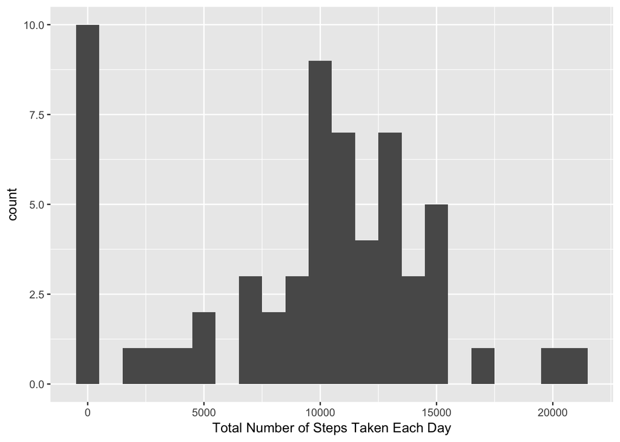

```r
library(ggplot2)
total.steps <- tapply(data$steps, data$date, FUN=sum, na.rm=TRUE)
qplot(total.steps, binwidth=1000, xlab="Total Number of Steps Taken Each Day")
```

Calculate and report the mean and median of the total number of steps taken per day

```r
mean(total.steps, na.rm=TRUE)
```

```
## [1] 9354.23
```

```r
median(total.steps, na.rm=TRUE)
```

```
## [1] 10395
```

## What is the average daily activity pattern?

Make a time series plot (i.e. 𝚝𝚢𝚙𝚎 = “𝚕”) of the 5-minute interval (x-axis) and the average number of steps taken, averaged across all days (y-axis)

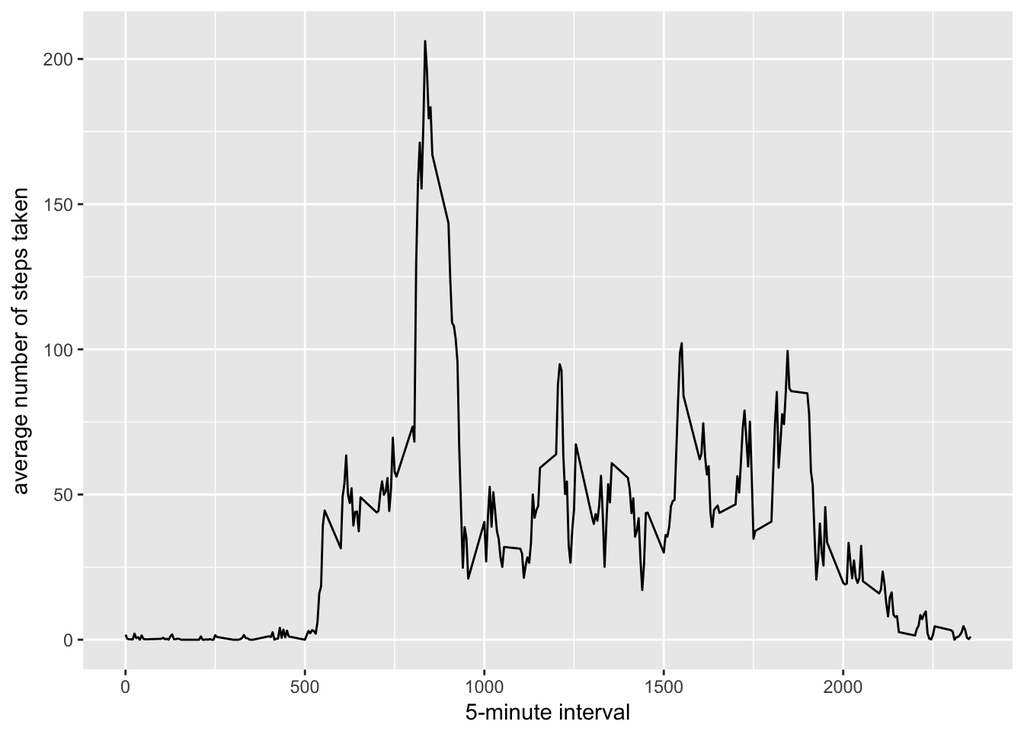

```r
library(ggplot2)
averages <- aggregate(x=list(steps=data$steps), by=list(interval=data$interval),
                      FUN=mean, na.rm=TRUE)
ggplot(data=averages, aes(x=interval, y=steps)) +
    geom_line() +
    xlab("5-minute interval") +
    ylab("average number of steps taken")
```

On average across all the days in the dataset, the 5-minute interval contains the maximum number of steps is below:

```r
averages[which.max(averages$steps),]
```

```
##     interval    steps
## 104      835 206.1698
```

## Imputing missing values

Note that there are a number of days/intervals where there are missing values (coded as 𝙽𝙰). The presence of missing days may introduce bias into some calculations or summaries of the data.

Calculate and report the total number of missing values in the dataset (i.e. the total number of rows with 𝙽𝙰s)

```r
sum(is.na(data))
```

```
## [1] 2304
```

The strategy we use here are the mean for that 5-minute interval.

Create a new dataset that is equal to the original dataset but with the missing data filled in.

```r
data.merged <- merge(data,averages, by="interval")
data.merged$steps.x[is.na(data.merged$steps.x)] <- data.merged$steps.y[is.na(data.merged$steps.x)]
```

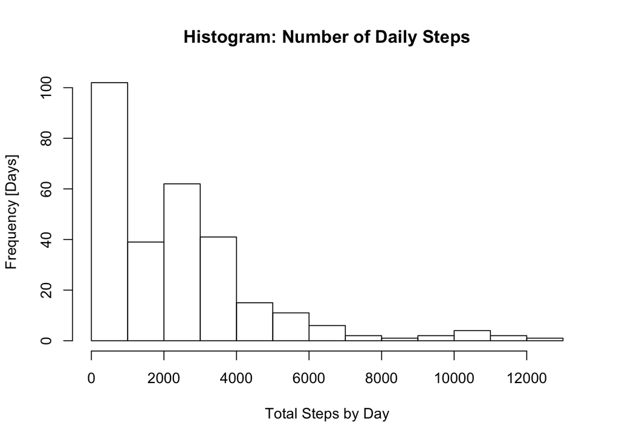

```r
data.merged <- aggregate(steps.x~interval,data.merged,sum)
hist(data.merged$steps.x, xlab="Total Steps by Day", ylab="Frequency [Days]",main="Histogram: Number of Daily Steps")
```

```r
mean2 <- mean(data.merged$steps, na.rm=TRUE)
median2 <- median(data.merged$steps, na.rm=TRUE)
```

[output not shown]

## Are there differences in activity patterns between weekdays and weekends?

For this part, we use the the 𝚠𝚎𝚎𝚔𝚍𝚊𝚢𝚜() function.

Create a new factor variable in the dataset with two levels – “weekday” and “weekend” indicating whether a given date is a weekday or weekend day.

```r
daytype <- function(date) {
    if (weekdays(as.Date(date)) %in% c("Saturday", "Sunday")) {
        "Weekend"
    } else {
        "Weekday"
    }
}
data$daytype <- as.factor(sapply(data$date, daytype))
str(data)
```

```
## 'data.frame':    17568 obs. of  4 variables:
##  $ steps   : int  NA NA NA NA NA NA NA NA NA NA ...
##  $ date    : Factor w/ 61 levels "2012-10-01","2012-10-02",..: 1 1 1 1 1 1 1 1 1 1 ...
##  $ interval: int  0 5 10 15 20 25 30 35 40 45 ...
##  $ daytype : Factor w/ 2 levels "Weekday","Weekend": 1 1 1 1 1 1 1 1 1 1 ...
```

Make a panel plot containing a time series plot (i.e. 𝚝𝚢𝚙𝚎 = “𝚕”) of the 5-minute interval (x-axis) and the average number of steps taken, averaged across all weekday days or weekend days (y-axis). See the README file in the GitHub repository to see an example of what this plot should look like using simulated data.

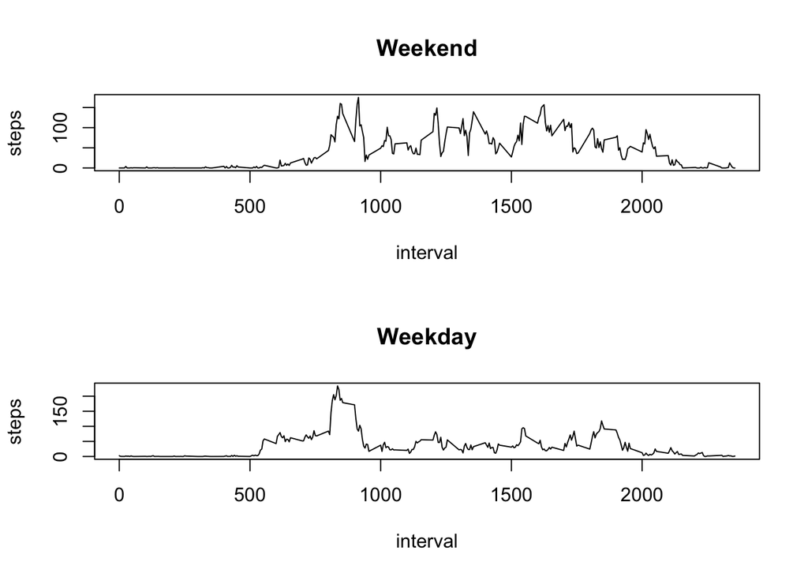

```r
par(mfrow=c(2,1))
for (type in c("Weekend", "Weekday")) {
    steps.type <- aggregate(steps ~ interval,
                            data=data,
                            subset=data$daytype==type,
                            FUN=mean)
    plot(steps.type, type="l", main=type)
}
```